# CrewAgent Product Positioning

# CrewAgent 产品定位 (CrewAgent Product Positioning)

## 1. 什么是 CrewAgent？

**CrewAgent** 是一个**面向专业领域的通用 Agent 操作系统**（Universal Agent Operating System）。它的核心愿景是让 AI 能够处理复杂的、长流程的专业工作，而不仅仅是简单的对话。

与通用的聊天助手不同，CrewAgent 在架构上彻底解耦了**“大脑”**（定义与逻辑）与**“双手”**（执行与工具）： * **平台端 (The Platform/Builder)**：一个云端可视化环境，专家（如 Simin）在这里定义工作流、提示词（Prompt）和逻辑，无需编写代码。 * **运行时 (The Runtime/Client)**：一个**本地优先（Local-First）**的桌面应用程序，在用户（如 David）的电脑上安全地执行这些工作流，直接操作本地文件、工具和数据。

这种架构将用户从“手动搬运数据的操作员”转变为**“数字专家的监督者”**，实现了“仿生（Bionic）”工作流——用云端的智慧驱动本地的工具，完成各种复杂的专业任务（无论是在软件开发、数据分析，还是未来的工业设计领域）。

目前，我们以 **BMAD 软件开发全生命周期（SDLC）** 作为最小案例实践（MVP），验证这一架构处理复杂专业任务的能力。

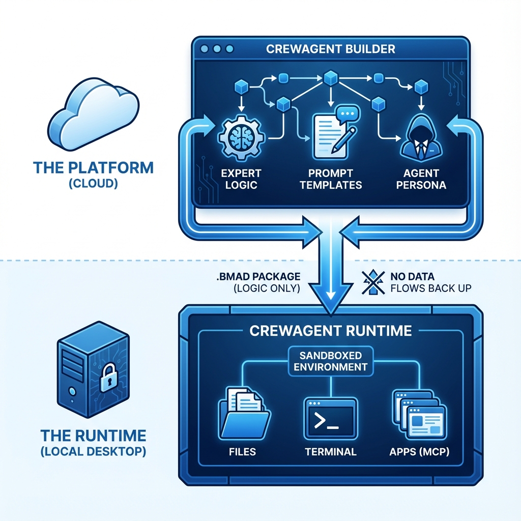

CrewAgent Architecture

## 2. 核心能力 (Capabilities)

CrewAgent 提供了一套完整的生态系统来创建和运行专业级 Agent：

### 面向创作者（Visual Builder）

- **无代码节点图 (No-Code Node Graph)**：通过拖拽界面设计复杂的业务逻辑和工作流，而非仅靠文字 Prompt。
- **仿生 Agent 定义 (Bionic Agent Definition)**：定义专门的角色、原则和工具策略。
- **包导出 (Package Export)**：一键将整个工作流导出为可移植的标准 **`.bmad` 包**（ZIP 格式）。
- **模板优先 (Template Library)**：提供经过验证的专业模式（如“参数校验流程”、“自动化报告生成”），让专家无需从零开始。

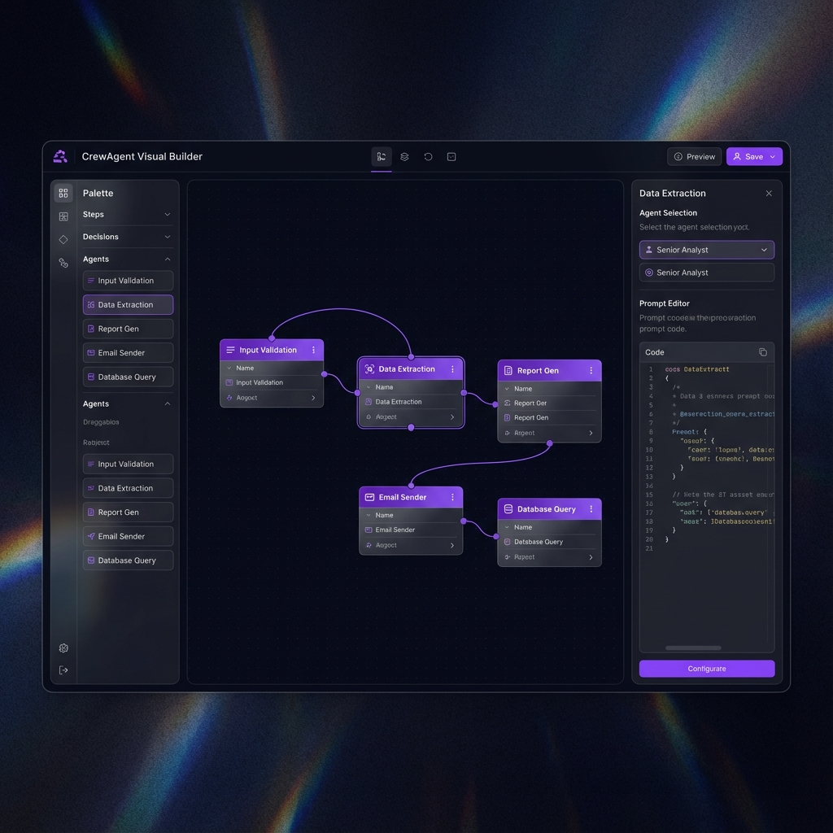

CrewAgent Visual Builder UI

### 面向消费者（Runtime Engine）

- **本地优先执行 (Local-First Execution)**：纯桌面端运行（macOS/Windows），确保数据隐私，且与本地工具（IDE、终端、Excel 等）无缝交互零延迟。
- **MCP 集成 (MCP Integration)**：原生支持 **Model Context Protocol (MCP)**，标准化了与本地工具（文件系统、终端、Python 环境、甚至未来的 CAD/ERP）的连接。
- **沙箱安全 (Sandboxed Security)**：严格限制文件系统的读写权限（仅限项目目录），防止 AI 误操作导致数据丢失或泄露。
- **离线/私有化支持 (Offline Trust)**：支持断网运行（激活后），并兼容本地大模型（如 Ollama），完美适配对数据安全极其敏感的场景。
- **可验证与可恢复 (Verifiable Output)**：“文档即状态（Document-as-State）”的架构确保每一步操作都记录在本地 Markdown 文件中，过程可审计，崩溃可恢复。

[figure not shown]

CrewAgent Runtime UI

## 3. 核心优势 (Core Advantages)

为什么选择 CrewAgent？因为它解决了专业级 AI 应用落地的四个核心痛点：

### 1. 数据主权与绝对隐私：我的地盘我做主

- **痛点**：在芯片设计、金融审计或法律咨询等领域，数据就是生命。企业不敢将核心代码库、财务底稿或机密图纸上传到云端 SaaS AI 平台（如 GPTs 或 Coze），因为一旦上传就意味着数据失控。
- **CrewAgent 优势**：**“逻辑在云端，数据在本地”**。CrewAgent 的 Runtime 运行在您的本地设备上。它只从云端下载“如何做任务”的逻辑（Prompt 和流程定义），但执行任务时产生的所有中间文件、读取的本地文档、生成的最终报告，**从未离开过您的设备**。您甚至可以在断网（Air-gapped）环境下配合本地大模型（如 Llama 3）运行，实现物理级的隐私安全。

### 2. 真·生产力：不仅是“建议者”，更是“执行者”

- **痛点**：大多数 ChatBot 即使接入了联网插件，也只能停留在“给建议”的层面。比如你让它“帮我重构代码”，它只能吐出一堆代码片段让你自己去复制粘贴，无法处理这就涉及 50 个文件联动的复杂任务。
- **CrewAgent 优势**：**“直接交付最终结果”**。CrewAgent 像一个真正的数字员工，拥有操作您文件系统的权限（当然是在沙箱内）。它可以打开您的项目文件夹，批量读取 100 份财报，提取数据生成 Excel，甚至直接修改代码仓库并提交 Git。它不再只是动嘴皮子，而是真正动手干活，交付的是“完成的工作”，而不只是“工作的建议”。

### 3. “专家定义，机器执行”的仿生架构：经验的无损复制

- **痛点**：行业知识（Know-How）很难传承。资深专家的经验往往在脑子里，难以通过文档教会新人；而让专家去写 Prompt 教 AI，又面临“专家不懂 AI，懂 AI 的不懂业务”的困境。
- **CrewAgent 优势**：**“SOP 的数字化与执行化”**。CrewAgent 提供了一个可视化的业务流程编排器，让业务专家（如资深律师）能像画流程图一样，将自己的办案逻辑固化下来（哪里需要检索、哪里需要校验、哪里需要生成）。这个定义好的“数字专家包（.bmad）”可以分发给任何初级律师。初级律师一键运行，就能获得资深合伙人级别的辅助，实现了隐性知识的规模化、标准化复制。

### 4. 打破工具孤岛：基于 MCP 的无限扩展

- **痛点**：传统的 RPA 或自动化工具，每对接一个新的企业软件（如 SAP、AutoCAD）都需要 lengthy 的定制开发。工具之间互不通气，形成了数据孤岛。
- **CrewAgent 优势**：**“标准协议连接万物”**。我们原生支持 Anthropic 提出的 MCP (Model Context Protocol) 开放标准。这意味着 CrewAgent 不再需要为每个软件单独开发插件，只要该软件（或社区）提供了 MCP 驱动，CrewAgent 就能即插即用。您可以轻松让 Agent 读取本地的 SQLite 数据库，或者调用本地的 Python 环境进行科学计算，打破了 SaaS AI 无法触及本地工具的壁垒。

## 4. 商业模式 (Business Model)

CrewAgent 采用混合模式，覆盖创造与执行两个环节：

1. **平台订阅 (Platform Fee - SaaS)**：面向“创作者”收取，提供高级可视化构建器、团队协作功能和云端库托管。
2. **桌面授权 (Seat License - Runtime)**：面向“企业/消费者”收取，提供安全、私有的本地运行时环境（可按席位或站点授权）。
3. **应用市场 (App Marketplace - 未来的可能性)**：未来允许专家销售他们构建的“行业包”（例如“自动化审计 Agent”），平台抽取佣金。

## 5. 交互模式：双重入口 (Dual Entry Modes)

CrewAgent 不仅是一个后台运行的流程引擎，它同时也提供了**“以 Agent 为中心”**的服务体验。系统支持两种入口模式，满足不同场景需求：

### 模式 A：Agent 优先 (Agent-First) —— 像咨询顾问一样服务

- **场景**：用户不确定具体要跑哪个流程，或者只是想找个帮手。
- **体验**：用户直接与 Agent（如“资深律师”）对话。Agent 提供一个**服务菜单 (Menu)**。用户可以说“我想起草个合同”，或者直接点击菜单。Agent 会根据用户的模糊指令，解析出意图，然后调起相应的后台工作流。
- **价值**：降低了使用门槛。用户不需要知道系统里有 100 个什么流程，只需要告诉 Agent “我想干什么”。

### 模式 B：流程优先 (Workflow-First) —— 像工厂开机一样执行

- **场景**：用户非常明确今天要处理这批数据，或者进行批量作业。
- **体验**：用户在项目面板直接选择“月度财报生成流程”，点击“运行”。系统直接进入高效执行模式，只有在缺少关键信息时才会停下来询问。
- **价值**：最高效的生产力工具。省去了寒暄和对话，直奔主题。

## 6. 竞品对比：CrewAgent vs. Dify vs. Coze

虽然都能构建“Agent”，但定位和架构截然不同。

| 特性 | **CrewAgent** | **Dify** | **Coze (扣子)** |
| --- | --- | --- | --- |
| **核心定位** | **专业桌面 Agent 系统** (本地优先) | **LLM 应用开发平台** (BaaS) | **社交/C端 Bot 搭建平台** |
| **主要用户** | 工程师、领域专家、专业工作者 | 开发者、初创团队、IT 部门 | 内容创作者、普通 C 端用户 |
| **执行环境** | **本地桌面 (Electron)** | 云端 / 服务器 (Docker) | 云端 (字节云) |
| **数据隐私** | **极高 (数据不离本地)** | 中 (数据流经其后端) | 低 (数据托管在云端) |
| **工具交互** | **直接操作本地** (文件, CLI, 软件) | API 调用 (HTTP 请求) | API + 社交平台插件 |
| **工作流类型** | **长流程/复杂任务** (文件处理/编码) | 请求/响应式 (API/对话为主) | 聊天机器人 / 互动流 |
| **核心差异** | **脑手分离架构 (云端定义/本地执行)** | 开源的 LLMOps 与 RAG 流水线 | 生态集成 (抖音/微信/飞书) |

### 差异总结

- **对比 Dify**：Dify 非常适合构建 **SaaS 应用**、**企业内部知识库**或**对外 API 服务**。它主要运行在服务器上，通过 API 服务多人。而 CrewAgent 专为**单人/本地的深度工作**设计，它可以直接操作你电脑上的文件（比如“帮我重构这个 1GB 的代码仓库”或“整理我磁盘里的 50 个 Excel”），这是运行在服务器上的 Dify 难以安全做到的。
- **对比 Coze**：Coze 是一个**消费级/社交级**的“玩乐场”或“轻工具”。你用它做 Bot 发到微信、Discord 聊天。它是一个“围墙花园”，运行在 Coze 服务器上。CrewAgent 是一个**生产力工具**，你用它来干正经的、复杂的活（写代码、做设计、搞分析），在一个安全、私密的本地环境中运行。

## 7. 深度技术差异：流程引擎 (Workflow Engine)

很多用户会问：“Dify 也有工作流（Workflow），你们的引擎有什么本质区别？”

这是最根本的架构分歧点：**“由谁来驱动流程？”**

### Dify/Coze 模式：编排器驱动 (Orchestrator-Driven)

- **机制**：类似于传统的工业流水线。平台的代码（Engine）是“工头”，LLM 只是“工人”。
- **流程**：代码说“现在执行第 1 步”，把输入喂给 LLM，LLM 吐出输出，代码拿到输出传给第 2 步。
- **局限**：非常死板。如果第 1 步失败了想重试，或者第 1 步发现资料不够需要临时查一下别的，传统的编排器很难处理这种动态变化，必须在画图时就把所有异常分支都画死。

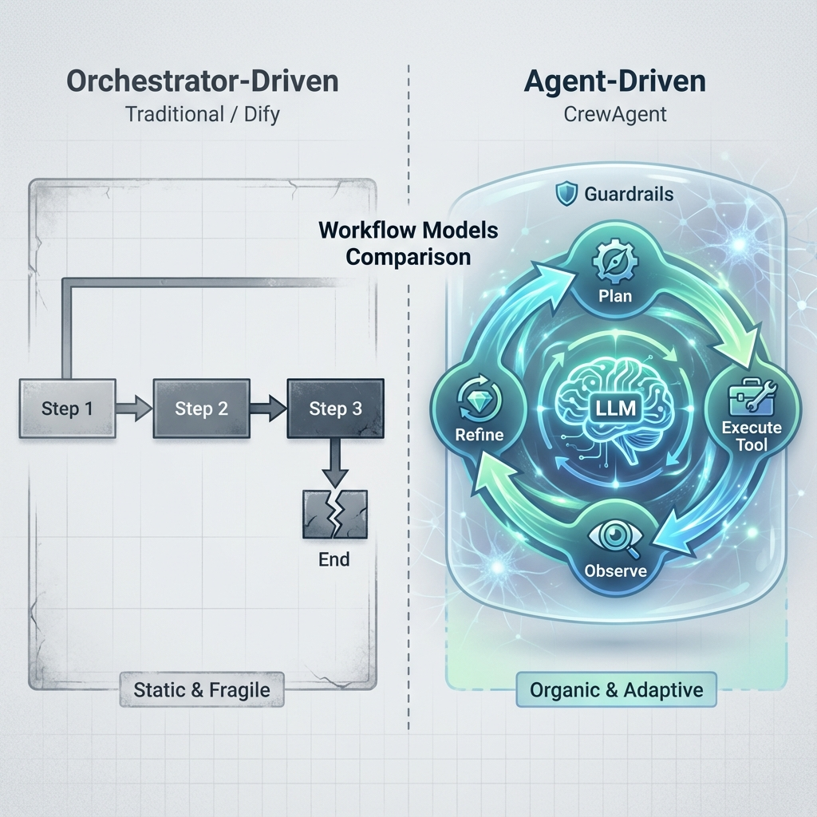

Workflow Engine Comparison

### CrewAgent 模式：Agent 驱动 (Agent-Driven with Guardrails)

- **机制**：**“LLM-as-Engine” (LLM 即引擎)**。CrewAgent 的 Runtime 只是一个“物理法则约束器”（负责文件读写、沙箱检查），而真正的“工头”是 LLM 本身。
- **流程**：LLM 读取当前的“案卷”（workflow.md），自己判断“我现在在第 1 步，为了完成这步，我需要先查资料，再写草稿，再检查一遍”。它可以在一个节点内自主地进行多次工具调用（循环、重试、修正），直到它认为满意了，再主动告诉 Runtime：“我完成了，申请进入下一步”。
- **优势**：**具备“主观能动性”**。它允许 Agent 在预定义的 SOP 框架内（图结构约束），拥有像人类专家一样的微观自主权（如何具体执行每一步）。这对于复杂的专业任务（如“写一个完备的法律意见书”）至关重要，因为这类任务很难用死板的 If/Else 流程图穷尽所有细节。